# Effective mass

MG

## T 24 L 6

$m_0^2 = -4.9 \quad$$m_1^2 = -4.9\quad$$\lambda_0^2 = 2.5\quad$$\lambda_1^2 = 2.5\quad$$\mu^2 = 5\quad$$g^2 = 0\quad$replica = 0

component n= 0

fit: $m_{eff}=0.266896\pm0.000787$

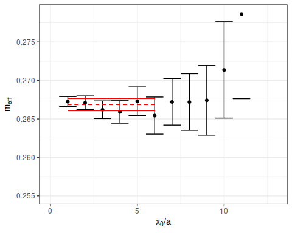

component n= 1

fit: $m_{eff}=0.267266\pm0.000839$

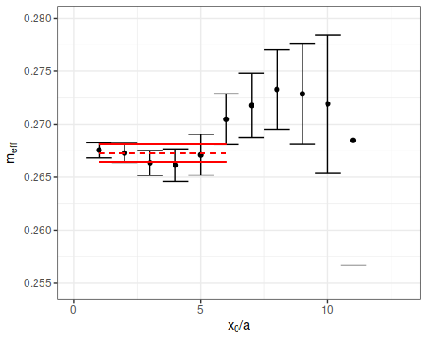

#### Two particle energy

component n= 0

fit: $m_{eff}=0.623867\pm0.001806$

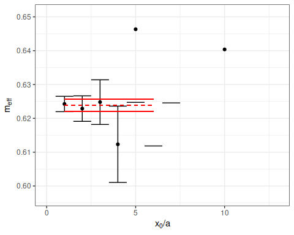

component n= 1

fit: $m_{eff}=0.624936\pm0.001775$

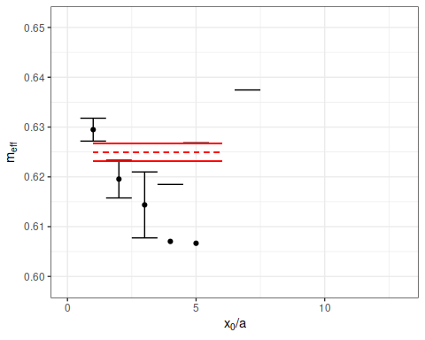

## T 24 L 8

$m_0^2 = -4.9 \quad$$m_1^2 = -4.9\quad$$\lambda_0^2 = 2.5\quad$$\lambda_1^2 = 2.5\quad$$\mu^2 = 5\quad$$g^2 = 0\quad$replica = 0

component n= 0

fit: $m_{eff}=0.233247\pm0.000704$

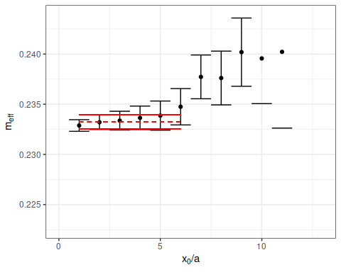

component n= 1

fit: $m_{eff}=0.233833\pm0.000728$

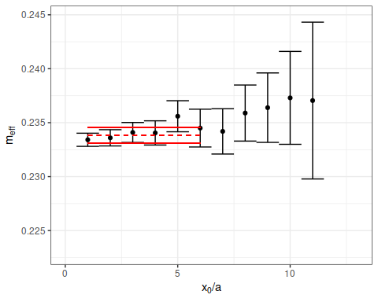

#### Two particle energy

component n= 0

fit: $m_{eff}=0.523245\pm0.001690$

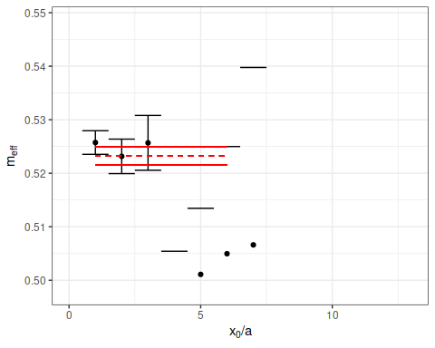

component n= 1

fit: $m_{eff}=0.519330\pm0.001660$

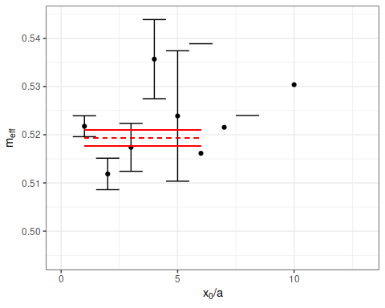

## T 24 L 10

$m_0^2 = -4.9 \quad$$m_1^2 = -4.9\quad$$\lambda_0^2 = 2.5\quad$$\lambda_1^2 = 2.5\quad$$\mu^2 = 5\quad$$g^2 = 0\quad$replica = 0

component n= 0

fit: $m_{eff}=0.218105\pm0.000715$

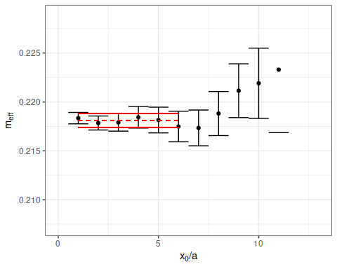

component n= 1

fit: $m_{eff}=0.218597\pm0.000702$

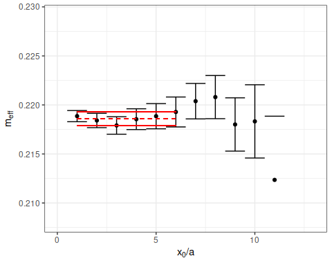

#### Two particle energy

component n= 0

fit: $m_{eff}=0.471108\pm0.001543$

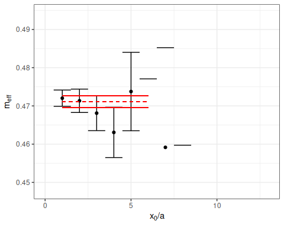

component n= 1

fit: $m_{eff}=0.471098\pm0.001641$

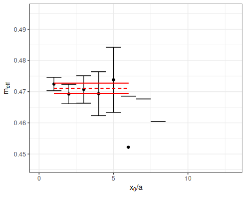

## T 48 L 24

$m_0^2 = -4.9 \quad$$m_1^2 = -4.9\quad$$\lambda_0^2 = 2.5\quad$$\lambda_1^2 = 2.5\quad$$\mu^2 = 5\quad$$g^2 = 0\quad$replica = 0

component n= 0

fit: $m_{eff}=0.204588\pm0.000511$

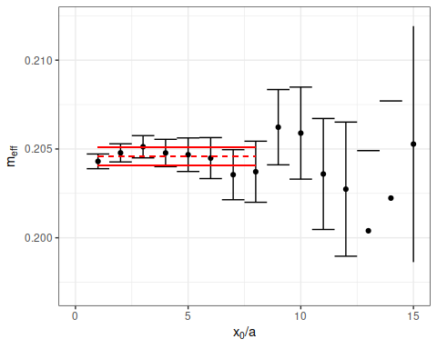

component n= 1

fit: $m_{eff}=0.203558\pm0.000507$

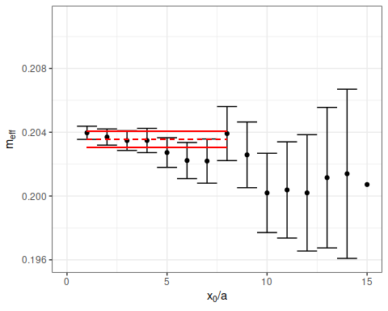

| L | T | meff0 | Emeff0 | meff1 | Emeff1 | E2 | E2err | E2.1 | E2err.1 |
| --- | --- | --- | --- | --- | --- | --- | --- | --- | --- |
| 6 | 24 | 0.2668961 | 0.0007874 | 0.2672665 | 0.0008387 | 0.6238673 | 0.0018059 | 0.6249356 | 0.0017746 |
| 8 | 24 | 0.2332467 | 0.0007041 | 0.2338333 | 0.0007275 | 0.5232449 | 0.0016904 | 0.5193303 | 0.0016604 |
| 10 | 24 | 0.2181055 | 0.0007153 | 0.2185968 | 0.0007025 | 0.4711081 | 0.0015434 | 0.4710976 | 0.0016412 |
| 24 | 48 | 0.2045875 | 0.0005107 | 0.2035583 | 0.0005069 | NA | NA | NA | NA |

# to be compared with the result of the paper https://arxiv.org/abs/1806.02367

| V1 | V2 | V3 | V4 | V5 | V6 | V7 | V8 | V9 |
| --- | --- | --- | --- | --- | --- | --- | --- | --- |
| L | T | nconf | ML | E2(L) | E3(L) | ∆E2 | ∆E3 | ∆E3/∆E2 |
| 4 | 24 | 18000 | 0.3634(16) | – | – | – | – | – |
| 5 | 24 | 28000 | 0.3049(13) | 0.6790(20) | 1.1121(93) | 0.0692(24) | 0.1973(97) | 2.85(12) |
| 6 | 24 | 7500 | 0.2684(24) | 0.5920(36) | 0.962(16) | 0.0552(46) | 0.156(17) | 2.83(26) |
| 7 | 24 | 30000 | 0.2479(12) | 0.5378(17) | 0.8669(74) | 0.0420(23) | 0.1233(79) | 2.93(17) |
| 8 | 24 | 47000 | 0.2355(10) | 0.5035(13) | 0.8006(57) | 0.0325(18) | 0.0941(62) | 2.90(17) |
| 9 | 24 | 40000 | 0.2247(11) | 0.4756(14) | 0.7574(62) | 0.0261(20) | 0.0832(67) | 3.19(24) |
| 10 | 24 | 70000 | 0.21843(85) | 0.4565(11) | 0.7103(46) | 0.0196(15) | 0.0550(50) | 2.80(23) |
| 11 | 24 | 30000 | 0.2142(13) | 0.4464(17) | 0.6859(71) | 0.0181(23) | 0.0434(77) | 2.40(37) |
| 12 | 24 | 12000 | 0.2095(21) | 0.4367(26) | 0.672(11) | 0.0177(37) | 0.043(12) | 2.43(60) |
| 13 | 24 | 20000 | 0.2088(16) | 0.4271(21) | 0.6546(91) | 0.0095(28) | 0.0282(98) | 2.97(97) |
| 14 | 24 | 28000 | 0.2054(22) | 0.4236(28) | 0.650(13) | 0.0127(38) | 0.034(14) | 2.64(96) |
| 15 | 24 | 40000 | 0.2057(12) | 0.4199(15) | 0.6362(66) | 0.0086(20) | 0.0192(70) | 2.23(72) |
| 16 | 24 | 52000 | 0.2045(14) | 0.4179(18) | 0.6347(83) | 0.0089(25) | 0.0211(88) | 2.37(88) |
| 17 | 24 | 70000 | 0.20540(87) | 0.4181(11) | 0.6388(50) | 0.0073(15) | 0.0226(54) | 3.11(71) |
| 18 | 24 | 36000 | 0.2051(12) | 0.4134(16) | 0.6371(71) | 0.0032(21) | 0.0218(76) | 6.8(4.0) |
| 20 | 24 | 70000 | 0.20477(87) | 0.4114(11) | 0.6241(52) | 0.0018(15) | 0.0098(55) | 5.4(4.1) |
| 14 | 48 | 36000 | 0.20724(33) | 0.42461(63) | 0.6530(23) | 0.01014(62) | 0.0313(24) | 3.09(20) |
| 24 | 48 | 100000 | 0.20426(55) | 0.4118(11) | 0.6194(58) | 0.0032(10) | 0.0066(59) | 2.0(1.7) |